# Multivariate Image Analysis in Thermal Imaging

## Overview

Multivariate image analysis can be very helpful in many perspectives in computer vision applications, since it performs an effective data analysis in the intensity, spatial, and temporal domains. It helps data analysts achieve both descriptive and predictive goals. Meanwhile, in an iterative knowledge discovery and understanding, human experts gain the insight of the data generation process, hence integrate human expertise to improve the machine-generated models. In this tutorial, we will present a case study of multivariate data analysis in a thermal imaging application. This will help the audience understand the basic concept of multivariate image analysis and how the principle works in a relative intuitive manner.

## Introduction

### Idletechs

[figure not shown]

The company **[Idletechs AS](https://www.idletechs.com)** develops new methods, software and solutions for better use of **Big Data streaming** from modern sensors such as hyperspectral cameras, thermal cameras etc. Our methodology is based on more than **47 years of R&D**, several books and several hundred research publications within multivariate data modelling of measurements. This research is now being [cited more than 1000 times per year](https://scholar.google.no/citations?user=60HNWsYAAAAJ&hl=no). Some of our most cited developments are: *Partial Least Squares Regression (PLSR)* for multivariate calibration, *Multiplicative Signal Correction (MSC)*, *Extended Multiplicative Signal Correction (EMSC)* for separation of physical and chemical effects om light measurements. We focus mainly on industrial, shipping and subsea solutions, for new ways to detect unwanted process changes and to help humans understand their overwhelming Big Data streams of measurements. But our physics- and observation-based hybrid modelling algorithms are generic, and we also have a number of **remote-sensing** and **aero-space activities**. We also have considerable generic competence of relevance for **satellite-based earth observation**. Briefly summarized, Idletechs’ satellite-related activities and competences are:

- Single-channel imaging time series
- Multi-channel spectral analyzers
- Hyperspectral imaging
- Hyperspectral “video” Big Data analyzed on a small computer
- Generic tools and competence of relevance to handling micro-satellite measurements

### Speaker

Dr. [**Ping Zhao**](https://idletechs.com/about-us/), Research Scientist, Email: ping.zhao@idletechs.com

## Summary

### Task

This tutorial illustrates the basic concept of multivariate data analysis and how the principle works in practice via a thermal imaging application. Given a pre-recorded thermal image sequence, the task is to analyze the data with no prior information. The goal is to discover the enclosed thermal varying patterns, recognize potential objects, and identify thermal events. In the following sections, a typical workflow of multivariate image analysis is presented. Each section has essential texts for the problem description, figures for the solution illustration, code for the detail understanding and verification, and discussions for the model interpretation.

### Dataset

[figure not shown]

Idletechs collected the data used in this tutorial from an experimental setup shown above. On the table, we place a waffle maker to the left, an electric iron in the center with an occluded electronic welding, a hamburger grill to the right, and a bottle of water next to the window. The sequence has 18,717 thermal images as a time series of temperature measurements over a certain period. Each image has 60 by 80 pixels, and each pixel is a temperature measurement at a specific moment at a specific spatial location from the camera’s point of view. The temperature may vary between 9 to 183 celsius degrees.

## Data Preprocessing

### Store Raw Data in a Matrix Form

The raw image data is a thermal time series stored in many CSV files. It can be time consuming to load them one by one while we improve our data analysis pipeline. We load all the images at once and restore them as **a compact matrix**. In a later phase, we load only the matrix to avoid loading and preprocessing overheads. A numerical matrix is a typical input to the multivariate image analysis. It has 18,717 rows, each of which corresponds to one thermal image, or in a different phase, one observation of all pixels at a specific moment; while, the 4800 (60 x 80) columns, each of which corresponds to the temperature variation of one pixel over the experimental period. In multivariate image analysis, we call one row in the input matrix as one **observation**, and one column as one **variable**.

```python
# Setup a logging system
import logging
logging.basicConfig(format='%(asctime)s %(levelname)s: %(message)s', level=logging.INFO)

# Point to the data folder
from os.path import join
data_folder = join('..', 'Data', 'ThermalDataSet_20170221')
pp_folder = join(data_folder, 'Preprocessed')
pp_file = join(pp_folder, 'reshaped_data_matrix.npz')

import numpy as np
from os.path import exists

# Load existing input matrix if possible
if exists(pp_file):
    logging.info('Loading raw data matrix and frame indices')

    with np.load(pp_file) as loaded_data:
        raw_data_matrix = loaded_data['raw_data_matrix']
        frame_inds = loaded_data['frame_inds']
        img_height = loaded_data['img_height']
        img_width = loaded_data['img_width']
        obs_num = raw_data_matrix.shape[0]
        var_num = raw_data_matrix.shape[1]

    logging.info('Loaded raw data matrix and frame indices')

# Generate the compact data matrix if necessary
else:
    img_height = None
    img_width = None
    var_num = None
    raw_data_matrix = None
    frame_inds = None

    # Create a list of CSV files
    import glob
    csv_folder = join(data_folder, 'CSV')
    csv_list = [f for f in sorted(glob.glob(join(csv_folder, "*.csv")))]
    obs_num = len(csv_list)

    # Iterate through all CSV files
    from os.path import basename
    logging.info('Reading all CSV files')
    for obs_ind in range(obs_num):
        csv_file = csv_list[obs_ind]
        base_name = basename(csv_file)

        # Output the progress for every 10 percent of data
        if obs_ind % np.ceil(obs_num * 0.1) == 0:
            logging.info('Reading CSV file %s', base_name)

        # Generate image frame indices
        if frame_inds is None:
            frame_inds = np.ndarray((obs_num))

        frame_inds[obs_ind] = np.float(base_name[0:6])

        # Load one image frame
        import pandas
        data = pandas.read_csv(csv_file, header=None, skiprows=2).to_numpy()

        # Collect image information
        if img_height is None:
            img_height = data.shape[0]
        else:
            if img_height != data.shape[0]:
                logging.error('Inconsistent image height in pixels: %s', base_name)
                continue

        if img_width is None:
            img_width = data.shape[1]
        else:
            if img_width != data.shape[1]:
                logging.error('Inconsistent image width in pixels: %s', base_name)
                continue

        if var_num is None:
            var_num = img_height * img_width

        if raw_data_matrix is None:
            raw_data_matrix = np.ndarray((obs_num, var_num))

        raw_data_matrix[obs_ind, :] = data.flatten()

    # Matrix generation is finished
    logging.info('Read all CSV files')

    # Save the input matrix for future reloading
    logging.info('Saving raw data matrix and frame indices')
    np.savez_compressed(pp_file,
                        raw_data_matrix=raw_data_matrix,
                        frame_inds=frame_inds,
                        img_height=img_height,
                        img_width=img_width,
                        allow_pickle=False)
    logging.info('Saved raw data matrix and frame indices')
```

```
2019-11-28 11:32:09,039 INFO: Reading all CSV files
2019-11-28 11:32:09,042 INFO: Reading CSV file 000001_thermalData.csv
2019-11-28 11:33:06,216 INFO: Reading CSV file 001871_thermalData.csv
2019-11-28 11:33:59,159 INFO: Reading CSV file 003741_thermalData.csv
2019-11-28 11:34:51,662 INFO: Reading CSV file 005611_thermalData.csv
2019-11-28 11:35:43,401 INFO: Reading CSV file 007864_thermalData.csv
2019-11-28 11:36:35,435 INFO: Reading CSV file 010735_thermalData.csv
2019-11-28 11:37:30,202 INFO: Reading CSV file 012764_thermalData.csv
2019-11-28 11:38:23,701 INFO: Reading CSV file 015920_thermalData.csv
2019-11-28 11:39:16,979 INFO: Reading CSV file 018878_thermalData.csv
2019-11-28 11:40:10,197 INFO: Reading CSV file 021957_thermalData.csv
2019-11-28 11:41:03,256 INFO: Read all CSV files
2019-11-28 11:41:03,257 INFO: Saving raw data matrix and frame indices
2019-11-28 11:41:35,625 INFO: Saved raw data matrix and frame indices
```

### Handle Incontinuous Frame Indices

The frame indices recorded as the variable **frame_inds** is incontinuous. This is likely because the data recorder did not report some data. This is not an obstacle to multivariate image analysis, but for the convenience of model interpretation we append **frame_inds** as one additional column to the input data matrix. The model construction process will exploit the correlation between the temporal information and thermal measurements if any.

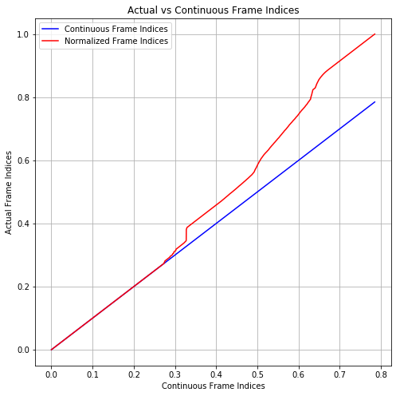

```python
import matplotlib.pyplot as plt

%matplotlib inline

continuous_frame_inds = range(len(frame_inds)) / np.max(frame_inds)
normalized_frame_inds = frame_inds / np.max(frame_inds)

# Generate a normalized dataset
normalized_data_matrix = raw_data_matrix / np.max(raw_data_matrix)
original_input_matrix = np.hstack((normalized_frame_inds.reshape(obs_num, 1), normalized_data_matrix))
inserted_col_num = original_input_matrix.shape[1] - var_num
extended_var_num = var_num + inserted_col_num

plt.figure(figsize=(8, 8))
plt.plot(continuous_frame_inds, continuous_frame_inds, 'b',
         continuous_frame_inds, normalized_frame_inds, 'r')
plt.xlabel('Continuous Frame Indices')
plt.ylabel('Actual Frame Indices')
plt.legend(['Continuous Frame Indices', 'Normalized Frame Indices'])
plt.grid(True)
plt.title('Actual vs Continuous Frame Indices')
plt.show()
```

## Model Construction

### Bilinear Model

For example, considering a simple case that the recorded time series data just a sequence of floating numbers. Let’s denote these observations with a variable $x$, then it can be rewritten as

$x = t \times q + c + \epsilon$,

where $q$ is a selected representative variable, $t$ is their scaling ratio, $c$ is their baseline difference which is a constant for a specific dataset, and $\epsilon$ is the error or lack of fit of the model to the data. In this way, the original variable $x$ is losslessly represented by another variable $q$. Since the collected data is essentially multivaraite, we rewrite the equation above by expanding both the dependent and independent variables to vectors,

$ \begin{pmatrix} X_{1}&...&X_{j}&...&X_{m} \end{pmatrix} = t \times \begin{pmatrix} Q_{1}&...&Q_{j}&...&Q_{m} \end{pmatrix} + \begin{pmatrix} C_{1}&...&C_{j}&...&C_{m} \end{pmatrix} + \begin{pmatrix} E_{1}&...&E_{j}&...&E_{m} \end{pmatrix} $,

To push this further, we stack all observations together, thus we get the input data as a matrix $X$,

$ X = \begin{pmatrix} X_{11}&...&X_{1j}&...&X_{1m}\\ ...&...&...&...&...\\ X_{i1}&...&X_{ij}&...&X_{im}\\ ...&...&...&...&...\\ X_{n1}&...&X_{nj}&...&X_{nm} \end{pmatrix} = \begin{pmatrix} T_{1}\\...\\T_{i}\\...\\T_{n} \end{pmatrix} \times \begin{pmatrix} Q_{1}&...&Q_{j}&...&Q_{m} \end{pmatrix} + \begin{pmatrix} C_{1}&...&C_{j}&...&C_{m}\\ ...&...&...&...&...\\ C_{1}&...&C_{j}&...&C_{m}\\ ...&...&...&...&...\\ C_{1}&...&C_{j}&...&C_{m} \end{pmatrix} + \begin{pmatrix} E_{11}&...&E_{1j}&...&E_{1m}\\ ...&...&...&...&...\\ E_{i1}&...&E_{ij}&...&E_{im}\\ ...&...&...&...&...\\ E_{n1}&...&E_{nj}&...&E_{nm} \end{pmatrix} $,

where $n$ is the number of observations. This representation is lossless, however it is not perfect. If any observation as the row vector $X_i$ has a relatively strong nonlinear relationship to the vector $Q$, then the absolute value of associated error $\epsilon_i$ will be large. One efficient way to reduce the absolute error is increasing the number of selected vector $Q$, then we have the following equation.

$ X = \begin{pmatrix} T_{11}&...&T_{1p}&...&T_{1k}\\ ...&...&...&...&...\\ T_{i1}&...&T_{ip}&...&T_{ik}\\ ...&...&...&...&...\\ T_{n1}&...&T_{nj}&...&T_{nk} \end{pmatrix} \times \begin{pmatrix} Q_{11}&...&Q_{1j}&...&Q_{1m}\\ ...&...&...&...&...\\ Q_{r1}&...&Q_{rj}&...&Q_{rm}\\ ...&...&...&...&...\\ Q_{k1}&...&Q_{kj}&...&Q_{km} \end{pmatrix} + \begin{pmatrix} C_{1}&...&C_{j}&...&C_{m}\\ ...&...&...&...&...\\ C_{1}&...&C_{j}&...&C_{m}\\ ...&...&...&...&...\\ C_{1}&...&C_{j}&...&C_{m} \end{pmatrix} + \begin{pmatrix} E_{11}&...&E_{1j}&...&E_{1m}\\ ...&...&...&...&...\\ E_{i1}&...&E_{ij}&...&E_{im}\\ ...&...&...&...&...\\ E_{n1}&...&E_{nj}&...&E_{nm} \end{pmatrix} $,

where $k$ is the number of selected vectors.

In this context, if we define a matrix $P$ as a transpose of the matrix $Q$

$ P = \begin{pmatrix} P_{11}&...&P_{1p}&...&P_{1k}\\ ...&...&...&...&...\\ P_{ij}&...&P_{ir}&...&P_{ik}\\ ...&...&...&...&...\\ P_{m1}&...&P_{mr}&...&P_{mk} \end{pmatrix} = \begin{pmatrix} Q_{11}&...&Q_{1j}&...&Q_{1m}\\ ...&...&...&...&...\\ Q_{r1}&...&Q_{rj}&...&Q_{rm}\\ ...&...&...&...&...\\ Q_{k1}&...&Q_{kj}&...&Q_{km} \end{pmatrix}^T $,

then we get the standard bilinear model written in a matrix form

$X = TP^T + C + E$,

where $T$ is commonly referred as score matrix, and $P$ is referred as loading matrix, in multivariate data analysis. The interpretation to this model is that all row vectors in $X$ are represented by a few column vectors in matrix $P$ by scaling them with coefficients defined in $T$ and shifting them by $C$ if you are willing to accept the errors presented in $E$. Does this sound familiar? Yes, this process defines a coordinate system may or may not be an Eucilidean version but an oblique version, since the selected column vectors in $P$ may not be orthogonal to each other. A geometrical illustration is shown below.

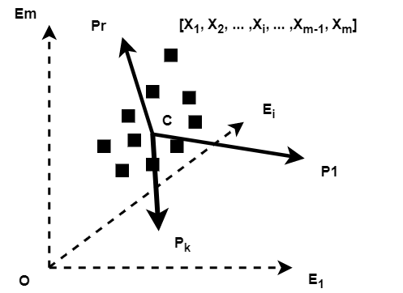

The original observation $\begin{pmatrix} X_{1}&...&X_{j}&...&X_{m} \end{pmatrix}$ in the coordinate system $\begin{pmatrix} E_{1}&...&E_{j}&...&E_{m} \end{pmatrix}$. After the linear transformation based on the bilinear model, the observation’s new coordinates are $\begin{pmatrix} P_{1}&...&P_{r}&...&P_{k} \end{pmatrix}$, where $k \ll m$. In this tutorial, $m = 4800$, while $k$ can go down even to 1 if the data analyst will accept large errors (lack of fit) in matrix $E$. Then the original $n \times m$ elements in matrix $X$ can be approximated by $(n + m) \times k + m$ elements. For example, in this tutorial after the transformation, we saved around $100 - ((18713 + 4800) * 3 + 4800)/(18713 * 4800) * 100 = 99.91$ percent of the storage space by losing a small amount of total variance in the data, provided the option $k = 3$ is used.

### Singular Value Decomposition

There are many methods and implementations can find a reasonable set of representative matrix $P$. One popular option is [Singular Value Decomposition](https://en.wikipedia.org/wiki/Singular_value_decomposition) In this tutorial, I selected the truncated version and used to archieve a fast and efficient matrix decomposition. The popular programming languages, such as, Python, Matlab, R, and Julia, have very good even built-in supports to this method. Truncated SVD creates a more “detailed” bilinear model $X = U \times S \times V^T + C + E$, where $V$ is mathmetically equivalent to $P$, $U \times S$ is equivalent to $T$, and $k$ reserves a large amount of data variance in $X$. The principal components (column vectors) in $P$ are guaranteed to be orthgonal to each other, and they are optimized and ranked to always point to the directions where the data has the largest variances. I show a geometrical illustration of truncated SVD as the figure below.

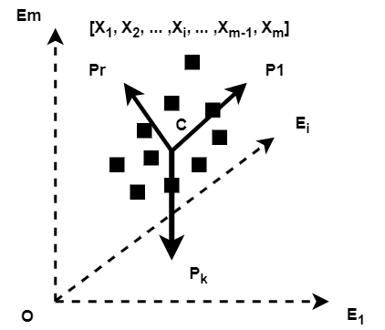

### Initial Data Inspection

#### Explained Variance

```python
import numpy as np
from copy import deepcopy
from numpy.linalg import svd
from scipy.sparse.linalg import svds

# https://en.wikipedia.org/wiki/Talk:Varimax_rotation
def varimax(Phi, gamma = 1.0, q = 20, tol = 1e-6):
    from numpy import eye, asarray, dot, sum, diag
    from numpy.linalg import svd

    p,k = Phi.shape
    R = eye(k)
    d=0
    for i in range(q):
        d_old = d
        Lambda = dot(Phi, R)
        u,s,vh = svd(dot(Phi.T,asarray(Lambda)**3 - (gamma/p) * dot(Lambda, diag(diag(dot(Lambda.T,Lambda))))))
        R = dot(u,vh)
        d = sum(s)
        if d_old!=0 and d/d_old < 1 + tol: break
    return dot(Phi, R)

# Remove emperical mean
#data_range = range(1, 18713)
#input_matrix = original_input_matrix[data_range, :]
#normalized_frame_inds = frame_inds / np.max(frame_inds)
#normalized_frame_inds = normalized_frame_inds[data_range]

input_matrix = original_input_matrix
center = np.mean(input_matrix, axis=0).reshape((1, input_matrix.shape[1]))
centered_matrix = input_matrix - center

total_var = np.sum(np.square(centered_matrix))

# Matrix decomposition
extracted_comp_num = 6
[u, s, vt] = svds(centered_matrix, k=extracted_comp_num, return_singular_vectors=True)

# Numpy has an inversed rank order of singular values
s = np.flip(s)
vt = np.flip(vt, axis=0)
loadings = vt.T
scores = np.dot(centered_matrix, loadings)

# Calculate explained variance
explained_var = np.zeros((extracted_comp_num))
for comp_ind in range(extracted_comp_num):
    score = scores[:, comp_ind].reshape((centered_matrix.shape[0], 1))
    loading = loadings[:, comp_ind].reshape((centered_matrix.shape[1], 1))
    recon_data = np.dot(score, loading.T)
    recon_comp_var = np.sum(np.square(recon_data))
    explained_var[comp_ind] = recon_comp_var / total_var * 100
explained_var = np.cumsum(explained_var)

rotated_loadings = varimax(loadings)

# Manual switch loading signs based on interpretation
for comp_ind in range(extracted_comp_num):
    max_ind = np.argmax(np.abs(rotated_loadings[:, comp_ind].flatten()))
    loading_sign = np.sign(rotated_loadings[max_ind, comp_ind])
    rotated_loadings[:, comp_ind] = loading_sign * rotated_loadings[:, comp_ind]

#rotated_loadings[:, 0] = -rotated_loadings[:, 0]
rotated_loadings[:, 1] = -rotated_loadings[:, 1]
#rotated_loadings[:, 2] = rotated_loadings[:, 2]

rotated_scores = np.dot(centered_matrix, rotated_loadings)
rotated_explained_var = np.zeros((extracted_comp_num))
for comp_ind in range(extracted_comp_num):
    rotated_score = rotated_scores[:, comp_ind].reshape((centered_matrix.shape[0], 1))
    rotated_loading = rotated_loadings[:, comp_ind].reshape((centered_matrix.shape[1], 1))
    rotated_recon_comp_var = np.sum(np.square(np.dot(rotated_score, rotated_loading.T)))
    rotated_explained_var[comp_ind] = rotated_recon_comp_var / total_var * 100
rotated_explained_var = np.cumsum(rotated_explained_var)
```

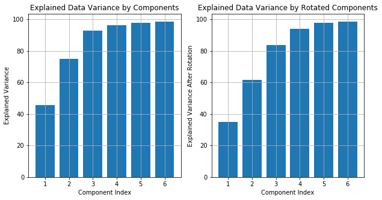

```python
import matplotlib.pyplot as plt

%matplotlib inline

plot_col_num = 2
plot_row_num = 1
plt.figure(figsize=(5 * plot_col_num, 5 * plot_row_num))

plt.subplot(1, 2, 1)
plt.bar(np.linspace(1, extracted_comp_num, extracted_comp_num), explained_var)
plt.grid(True)
plt.xlabel('Component Index')
plt.ylabel('Explained Variance')
plt.title('Explained Data Variance by Components')

plt.subplot(1, 2, 2)
plt.bar(np.linspace(1, extracted_comp_num, extracted_comp_num), rotated_explained_var)
plt.grid(True)
plt.xlabel('Component Index')
plt.ylabel('Explained Variance After Rotation')
plt.title('Explained Data Variance by Rotated Components')

plt.show()
```

#### Loading Plot

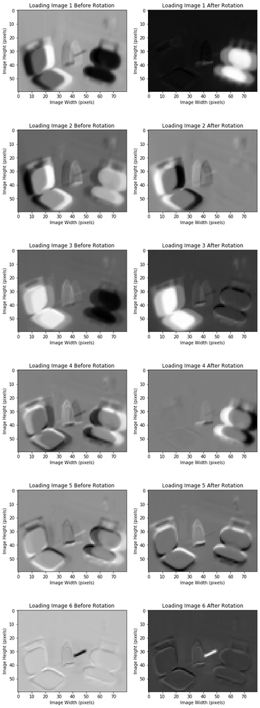

```python
import matplotlib.pyplot as plt

%matplotlib inline

plot_col_num = 2
plot_row_num = extracted_comp_num
bin_num = np.int(np.ceil(var_num / 100))

plt.figure(figsize=(5 * plot_col_num, 5 * plot_row_num))
for comp_ind in range(extracted_comp_num):
    loading_img = loadings[inserted_col_num:, comp_ind].reshape((img_height, img_width))
    plt.subplot(plot_row_num, plot_col_num, comp_ind * plot_col_num + 1)
    plt.imshow(loading_img, cmap='gray')
    plt.xlabel('Image Width (pixels)')
    plt.ylabel('Image Height (pixels)')
    plt.title('Loading Image ' + str(comp_ind + 1) + ' Before Rotation')

    rotated_loading_img = rotated_loadings[inserted_col_num:None, comp_ind].reshape((img_height, img_width))
    plt.subplot(plot_row_num, plot_col_num, comp_ind * plot_col_num + 2
               )
    plt.imshow(rotated_loading_img, cmap='gray')
    plt.xlabel('Image Width (pixels)')
    plt.ylabel('Image Height (pixels)')
    plt.title('Loading Image ' + str(comp_ind + 1) + ' After Rotation')

plt.show()
```

#### Score Plot

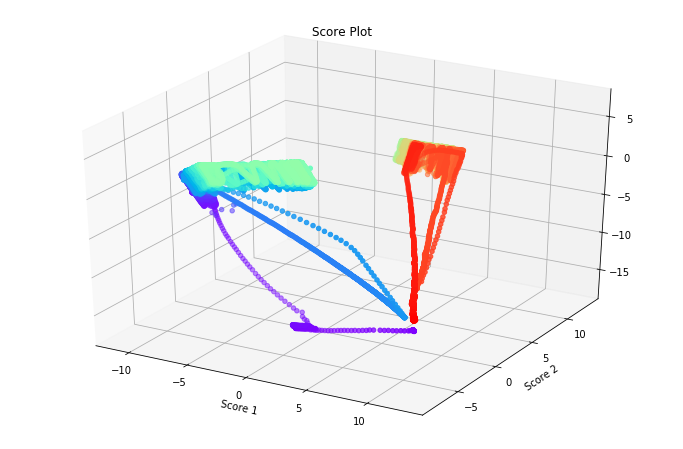

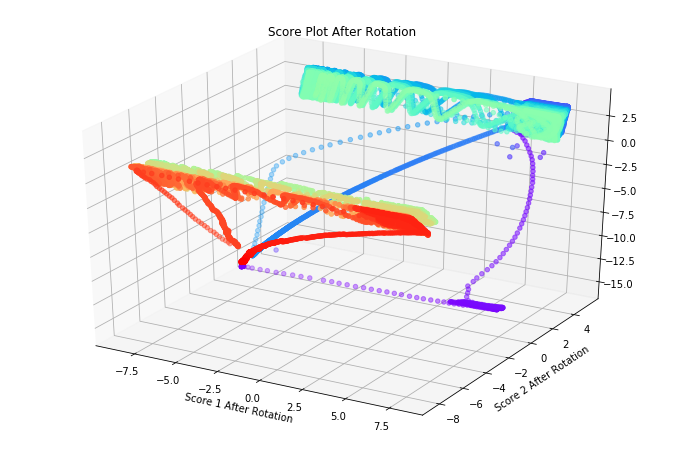

```python
from mpl_toolkits import mplot3d
import matplotlib.pyplot as plt

%matplotlib inline

plt.figure(figsize=(12, 8))
ax = plt.axes(projection="3d")
ax.scatter3D(scores[:, 0], scores[:, 1], scores[:, 2], c=normalized_frame_inds, cmap='rainbow');
plt.grid(True)
plt.xlabel('Score 1')
plt.ylabel('Score 2')
plt.title('Score Plot')

plt.figure(figsize=(12, 8))
ax = plt.axes(projection="3d")
ax.scatter3D(rotated_scores[:, 0], rotated_scores[:, 1], rotated_scores[:, 2], c=normalized_frame_inds, cmap='rainbow');
plt.grid(True)
plt.xlabel('Score 1 After Rotation')
plt.ylabel('Score 2 After Rotation')
plt.title('Score Plot After Rotation')

plt.show()
```

## Inspect Thermal Stages

```python
def inspect_thermal_stage(first_frame, last_frame, comp_inds, frame_inds, scores):
    first_frame_ind = np.argwhere(frame_inds == first_frame)
    last_frame_ind = np.argwhere(frame_inds == last_frame)

    frame_count = last_frame_ind - first_frame_ind + 1
    obs_range = np.linspace(first_frame_ind, last_frame_ind, frame_count, dtype=np.int).flatten()

    comp_num = np.max(comp_inds) + 1
    plot_row_num = 1
    plot_col_num = comp_num

    plt.figure(figsize=(5 * plot_col_num, 5 * plot_row_num))
    for ind in range(comp_num):
        comp_ind = comp_inds[ind]
        plt.subplot(plot_row_num, plot_col_num, ind + 1)
        plt.plot(frame_inds[obs_range], scores[obs_range, comp_ind])
        plt.xlabel('Frame Index')
        plt.ylabel('Score ' + str(comp_ind))
        plt.grid(True)
        plt.title('Score ' + str(comp_ind))

    [u, s, vt] = svds(centered_matrix[obs_range, :], k=comp_num, return_singular_vectors=True)
    s = np.flip(s)
    vt = np.flip(vt, axis=0)
    loadings = vt.T

    for ind in range(comp_num):
        comp_ind = comp_inds[ind]
        max_ind = np.argmax(np.abs(loadings[:, comp_ind].flatten()))
        loading_sign = np.sign(loadings[max_ind, comp_ind])
        loadings[:, comp_ind] = loading_sign * loadings[:, comp_ind]

    plt.figure(figsize=(5 * plot_col_num, 5 * plot_row_num))
    for ind in range(comp_num):
        comp_ind = comp_inds[ind]
        loading_img = loadings[inserted_col_num:, comp_ind].reshape((img_height, img_width))
        plt.subplot(plot_row_num, plot_col_num, ind + 1)
        plt.imshow(loading_img, cmap='gray')

    plt.show()

%matplotlib inline
```

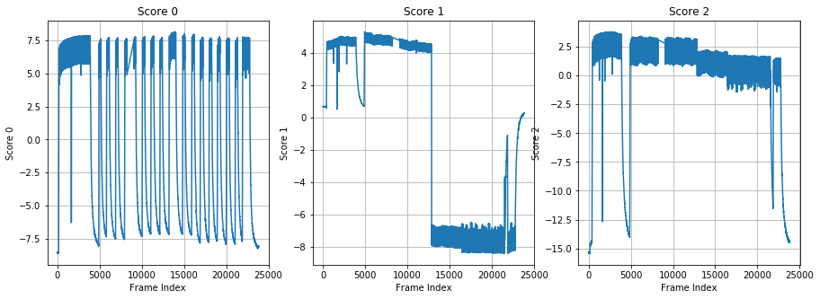

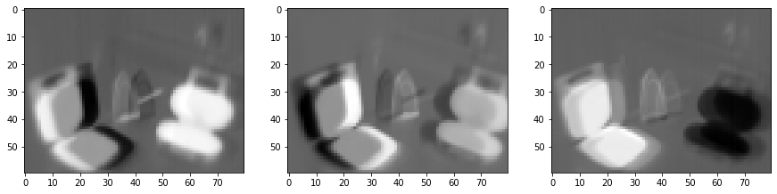

```python
inspect_thermal_stage(1, np.max(frame_inds), (0, 1, 2), frame_inds, rotated_scores)
```

### Initial Thermal Environment

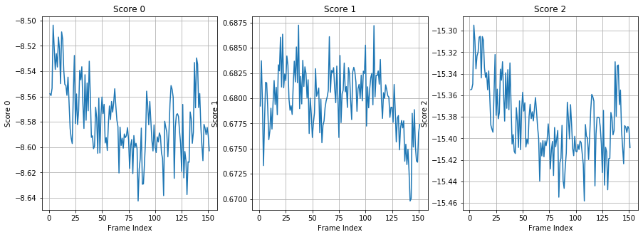

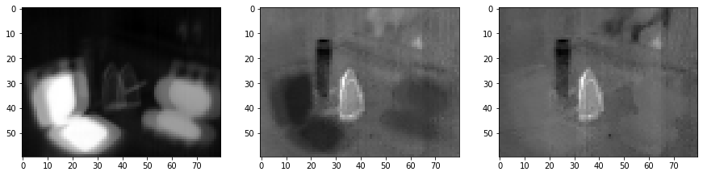

```python
inspect_thermal_stage(1, 151, (0, 1, 2), frame_inds, rotated_scores)
```

### Heating Up of Object 1

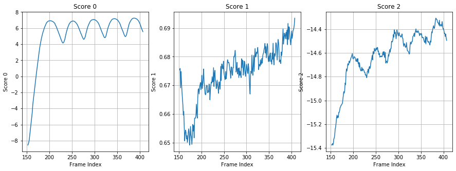

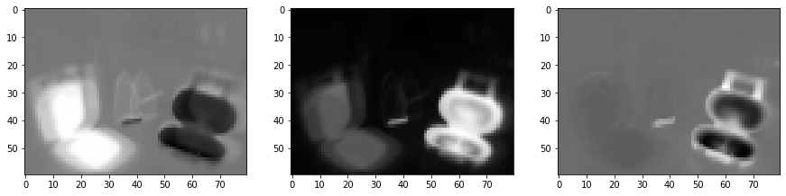

```python
inspect_thermal_stage(152, 407, (0, 1, 2), frame_inds, rotated_scores)
```

### Cooling Down of Object 1 and Heating Up of Object 2

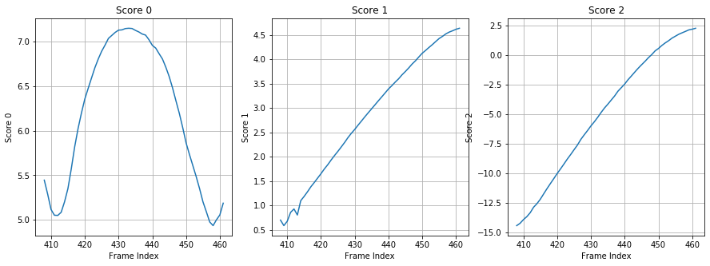

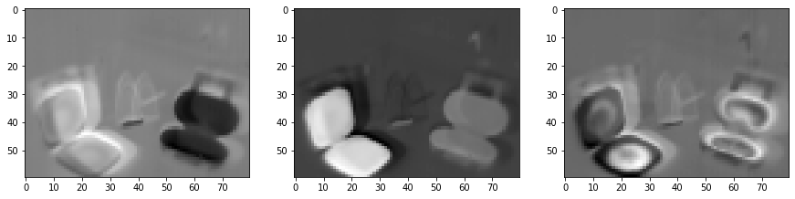

```python
inspect_thermal_stage(408, 461, (0, 1, 2), frame_inds, rotated_scores)
```

### Thermal Oscillation of Object 1 and 2

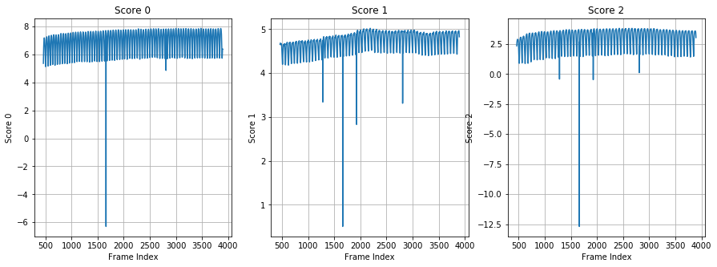

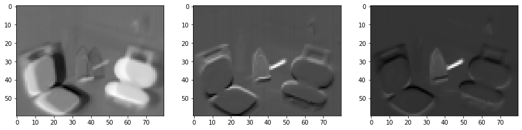

```python
inspect_thermal_stage(462, 3896, (0, 1, 2), frame_inds, rotated_scores)
```

### Cooling Down of Object 1 and 2

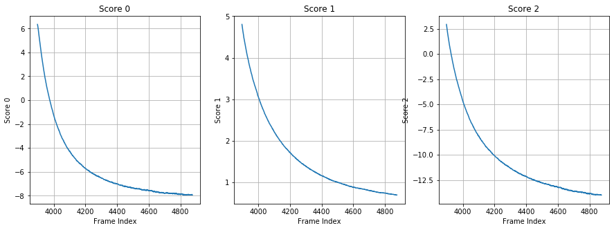

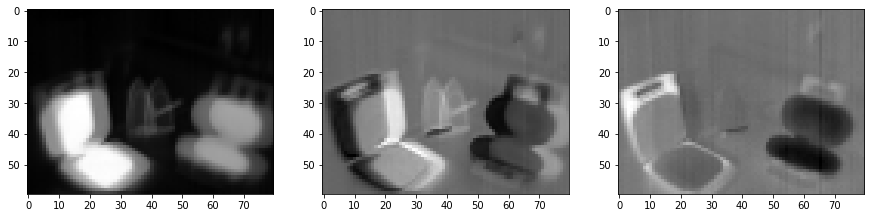

```python
inspect_thermal_stage(3897, 4875, (0, 1, 2), frame_inds, rotated_scores)
```

### Thermal Oscillation of Object 1 and 2 Again

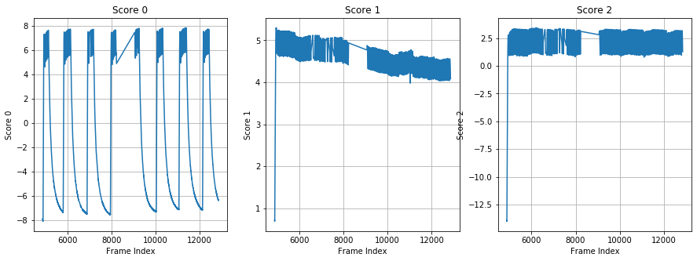

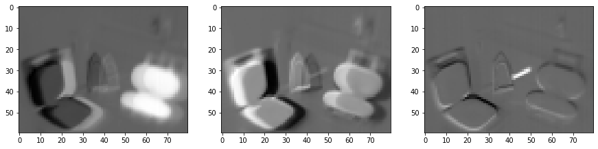

```python
inspect_thermal_stage(4876, 12856, (0, 1, 2), frame_inds, rotated_scores)
```

### Camera Shift and Thermal Oscillation of Object 1 and 2

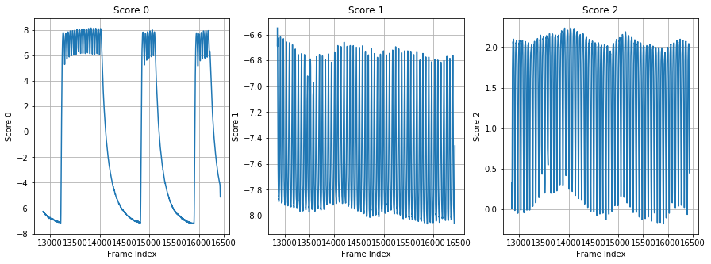

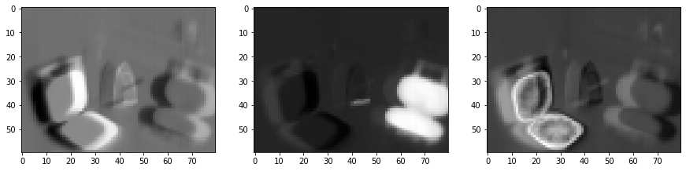

```python
inspect_thermal_stage(12857, 16432, (0, 1, 2), frame_inds, rotated_scores)
```

### Object 3 is Involved

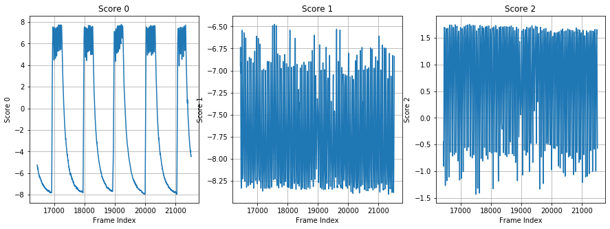

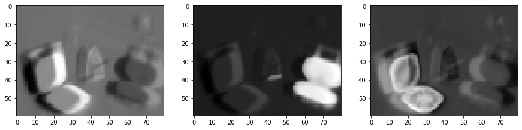

```python
inspect_thermal_stage(16434, 21522, (0, 1, 2), frame_inds, rotated_scores)
```

### The Rest

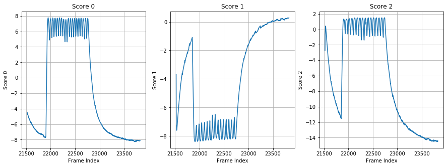

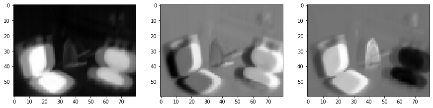

```python
inspect_thermal_stage(21523, 23826, (0, 1, 2), frame_inds, rotated_scores)
```

## Model Remastered

### Model for An Individual Stage

```python
import numpy as np
from copy import deepcopy
from numpy.linalg import svd
from scipy.sparse.linalg import svds

# Remove emperical mean
data_range = range(200, 407)
input_matrix = original_input_matrix[data_range, :]
normalized_frame_inds = frame_inds[data_range] / np.max(frame_inds[data_range])

center = np.mean(input_matrix, axis=0).reshape((1, input_matrix.shape[1]))
centered_matrix = input_matrix - center
total_var = np.sum(np.square(centered_matrix))

# Matrix decomposition
extracted_comp_num = 3
[u, s, vt] = svds(centered_matrix, k=extracted_comp_num, return_singular_vectors=True)

# Numpy has an inversed rank order of singular values
s = np.flip(s)
vt = np.flip(vt, axis=0)
loadings = vt.T
rotated_loadings = varimax(loadings)

# Manual switch loading signs based on interpretation
for comp_ind in range(extracted_comp_num):
    max_ind = np.argmax(np.abs(rotated_loadings[:, comp_ind].flatten()))
    loading_sign = np.sign(rotated_loadings[max_ind, comp_ind])
    rotated_loadings[:, comp_ind] = loading_sign * rotated_loadings[:, comp_ind]

#rotated_loadings[:, 0] = -rotated_loadings[:, 0]
#rotated_loadings[:, 1] = -rotated_loadings[:, 1]
#rotated_loadings[:, 2] = rotated_loadings[:, 2]

rotated_scores = np.dot(centered_matrix, rotated_loadings)
rotated_explained_var = np.zeros((extracted_comp_num))
for comp_ind in range(extracted_comp_num):
    rotated_score = rotated_scores[:, comp_ind].reshape((centered_matrix.shape[0], 1))
    rotated_loading = rotated_loadings[:, comp_ind].reshape((centered_matrix.shape[1], 1))
    rotated_recon_comp_var = np.sum(np.square(np.dot(rotated_score, rotated_loading.T)))
    rotated_explained_var[comp_ind] = rotated_recon_comp_var / total_var * 100
rotated_explained_var = np.cumsum(rotated_explained_var)
```

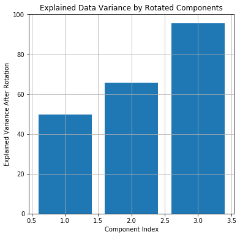

```python
import matplotlib.pyplot as plt

%matplotlib inline

plot_col_num = 1
plot_row_num = 1
plt.figure(figsize=(6 * plot_col_num, 6 * plot_row_num))

plt.bar(np.linspace(1, extracted_comp_num, extracted_comp_num), rotated_explained_var)
plt.grid(True)
plt.xlabel('Component Index')
plt.ylabel('Explained Variance After Rotation')
plt.title('Explained Data Variance by Rotated Components')

plt.show()
```

### Loading Plot

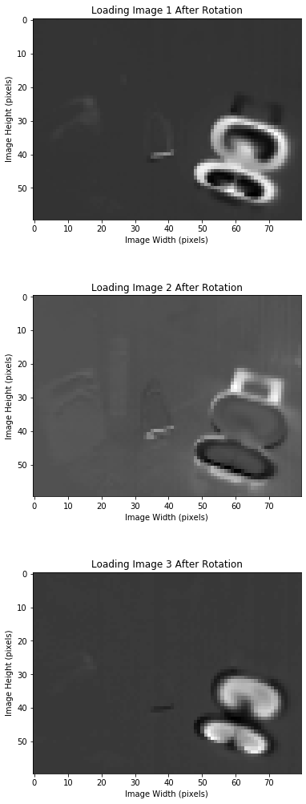

```python
import matplotlib.pyplot as plt

%matplotlib inline

plot_col_num = 1
plot_row_num = extracted_comp_num
bin_num = np.int(np.ceil(var_num / 100))

plt.figure(figsize=(6 * plot_col_num, 6 * plot_row_num))
for comp_ind in range(extracted_comp_num):
    rotated_loading_img = rotated_loadings[inserted_col_num:None, comp_ind].reshape((img_height, img_width))
    plt.subplot(plot_row_num, plot_col_num, comp_ind * plot_col_num + 1)
    plt.imshow(rotated_loading_img, cmap='gray')
    plt.xlabel('Image Width (pixels)')
    plt.ylabel('Image Height (pixels)')
    plt.title('Loading Image ' + str(comp_ind + 1) + ' After Rotation')

plt.show()
```

### Score Plot

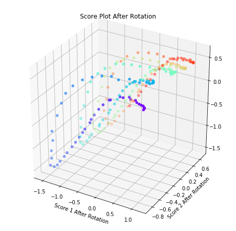

```python
from mpl_toolkits import mplot3d
import matplotlib.pyplot as plt

%matplotlib inline

plt.figure(figsize=(8, 8))
ax = plt.axes(projection="3d")
ax.scatter3D(rotated_scores[:, 0], rotated_scores[:, 1], rotated_scores[:, 2], c=normalized_frame_inds, cmap='rainbow');
plt.grid(True)
plt.xlabel('Score 1 After Rotation')
plt.ylabel('Score 2 After Rotation')
plt.title('Score Plot After Rotation')

plt.show()
```

## Conclusion

Multivariate data analysis is very helpful in thermal imaging applications, and it has the following advantages:

1. Works with any input matrix with essential data variance
2. Works even the observation number is less than the variable number
3. Make no model assumption, perfect for knowledge discovery
4. Tremendously reduce the data volume
5. Perform data analysis simutaneously in intensity, spatial, and temporal domains
6. Semi-supervised and very friendly to integrating human experitise
7. Simplify the data complex while reserving the linear relationship between observations

Also a few disadvantages:

1. Classic multivariate data analysis uses no spatial information
2. Can be sensitive to noises, robust variant is needed
3. Iterative improvement is required for creating a good model